# Face Generation

In this project, you'll use generative adversarial networks to generate new images of faces.

### Get the Data

You'll be using two datasets in this project:

- MNIST
- CelebA

Since the celebA dataset is complex and you're doing GANs in a project for the first time, we want you to test your neural network on MNIST before CelebA. Running the GANs on MNIST will allow you to see how well your model trains sooner.

If you're using [FloydHub](https://www.floydhub.com/), set `data_dir` to "/input" and use the [FloydHub data ID](http://docs.floydhub.com/home/using_datasets/) "R5KrjnANiKVhLWAkpXhNBe".

```python
data_dir = './data'

# FloydHub - Use with data ID "R5KrjnANiKVhLWAkpXhNBe"
data_dir = '/input'


"""
DON'T MODIFY ANYTHING IN THIS CELL
"""
import helper

helper.download_extract('mnist', data_dir)
helper.download_extract('celeba', data_dir)
```

```
Found mnist Data
Found celeba Data
```

## Explore the Data

### MNIST

As you're aware, the [MNIST](http://yann.lecun.com/exdb/mnist/) dataset contains images of handwritten digits. You can view the first number of examples by changing `show_n_images`.

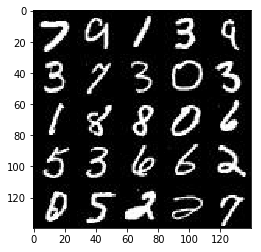

```python
show_n_images = 25

"""
DON'T MODIFY ANYTHING IN THIS CELL
"""
%matplotlib inline
import os
from glob import glob
from matplotlib import pyplot

mnist_images = helper.get_batch(glob(os.path.join(data_dir, 'mnist/*.jpg'))[:show_n_images], 28, 28, 'L')
pyplot.imshow(helper.images_square_grid(mnist_images, 'L'), cmap='gray')
```

### CelebA

The [CelebFaces Attributes Dataset (CelebA)](http://mmlab.ie.cuhk.edu.hk/projects/CelebA.html) dataset contains over 200,000 celebrity images with annotations. Since you're going to be generating faces, you won't need the annotations. You can view the first number of examples by changing `show_n_images`.

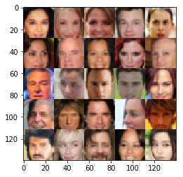

```python
show_n_images = 25

"""
DON'T MODIFY ANYTHING IN THIS CELL
"""
mnist_images = helper.get_batch(glob(os.path.join(data_dir, 'img_align_celeba/*.jpg'))[:show_n_images], 28, 28, 'RGB')
pyplot.imshow(helper.images_square_grid(mnist_images, 'RGB'))
```

## Preprocess the Data

Since the project's main focus is on building the GANs, we'll preprocess the data for you. The values of the MNIST and CelebA dataset will be in the range of -0.5 to 0.5 of 28x28 dimensional images. The CelebA images will be cropped to remove parts of the image that don't include a face, then resized down to 28x28.

The MNIST images are black and white images with a single color channel while the CelebA images have 3 color channels (RGB color channel).

## Build the Neural Network

You'll build the components necessary to build a GANs by implementing the following functions below:

- `model_inputs`
- `discriminator`
- `generator`
- `model_loss`
- `model_opt`
- `train`

### Check the Version of TensorFlow and Access to GPU

This will check to make sure you have the correct version of TensorFlow and access to a GPU

```python
"""
DON'T MODIFY ANYTHING IN THIS CELL
"""
from distutils.version import LooseVersion
import warnings
import tensorflow as tf

# Check TensorFlow Version
assert LooseVersion(tf.__version__) >= LooseVersion('1.0'), 'Please use TensorFlow version 1.0 or newer.  You are using {}'.format(tf.__version__)
print('TensorFlow Version: {}'.format(tf.__version__))

# Check for a GPU
if not tf.test.gpu_device_name():
    warnings.warn('No GPU found. Please use a GPU to train your neural network.')
else:
    print('Default GPU Device: {}'.format(tf.test.gpu_device_name()))
```

```
TensorFlow Version: 1.0.0
Default GPU Device: /gpu:0
```

### Input

Implement the `model_inputs` function to create TF Placeholders for the Neural Network. It should create the following placeholders:

- Real input images placeholder with rank 4 using `image_width`, `image_height`, and `image_channels`.
- Z input placeholder with rank 2 using `z_dim`.
- Learning rate placeholder with rank 0.

Return the placeholders in the following the tuple (tensor of real input images, tensor of z data)

```python
import problem_unittests as tests

def model_inputs(image_width, image_height, image_channels, z_dim):
    """
    Create the model inputs
    :param image_width: The input image width
    :param image_height: The input image height
    :param image_channels: The number of image channels
    :param z_dim: The dimension of Z
    :return: Tuple of (tensor of real input images, tensor of z data, learning rate)
    """
    real_input = tf.placeholder(tf.float32, [None, image_width, image_height, image_channels], name="real_input")
    z_input = tf.placeholder(tf.float32, [None, z_dim], name="z_input")
    learning_rate = tf.placeholder(tf.float32, name="learning_rate")

    return real_input, z_input, learning_rate


"""
DON'T MODIFY ANYTHING IN THIS CELL THAT IS BELOW THIS LINE
"""
tests.test_model_inputs(model_inputs)
```

```
Tests Passed
```

### Discriminator

Implement `discriminator` to create a discriminator neural network that discriminates on `images`. This function should be able to reuse the variabes in the neural network. Use [`tf.variable_scope`](https://www.tensorflow.org/api_docs/python/tf/variable_scope) with a scope name of "discriminator" to allow the variables to be reused. The function should return a tuple of (tensor output of the discriminator, tensor logits of the discriminator).

```python
def leaky_relu(input, alpha=0.2, name="leaky_relu"):
    return tf.maximum(input, alpha * input, name=name)
```

```python
def discriminator(images, reuse=False, keep_prob=0.9):
    """
    Create the discriminator network
    :param image: Tensor of input image(s)
    :param reuse: Boolean if the weights should be reused
    :return: Tuple of (tensor output of the discriminator, tensor logits of the discriminator)
    """
    with tf.variable_scope("discriminator", reuse=reuse):
        # convert 28x28x(input_dimension) into 14x14x64
        layer1 = tf.layers.conv2d(images, 64, 5, 2, 'same', kernel_initializer=tf.contrib.layers.xavier_initializer(True))
        layer1 = leaky_relu(layer1)
        layer1 = tf.nn.dropout(layer1, keep_prob=keep_prob)
        #layer1 = tf.Print(layer1, [tf.shape(layer1)], "discriminator layer 1 shape", summarize=100)

        # convert 14x14x64 into 7x7x128
        layer2 = tf.layers.conv2d(layer1, 128, 5, 2, 'same', kernel_initializer=tf.contrib.layers.xavier_initializer(True))
        layer2 = tf.layers.batch_normalization(layer2, training=True)
        layer2 = leaky_relu(layer2)
        layer2 = tf.nn.dropout(layer2, keep_prob=keep_prob)
        #layer2 = tf.Print(layer2, [tf.shape(layer2)], "discriminator layer 2 shape", summarize=100)

        # removed a layer as suggested by reviewer
        # convert 7x7x128 into 4x4x256
        #layer3 = tf.layers.conv2d(layer2, 256, 5, 2, 'same', kernel_initializer=tf.contrib.layers.xavier_initializer(True))
        #layer3 = tf.layers.batch_normalization(layer3, training=True)
        #layer3 = tf.maximum(alpha * layer3, layer3)
        #layer3 = tf.nn.dropout(layer3, keep_prob=keep_prob)
        #layer3 = tf.Print(layer3, [tf.shape(layer3)], "discriminator layer 3 shape", summarize=100)

        # flatten to linear array
        convolutions_output = tf.reshape(layer2, (-1, 7 * 7 * 128))

        logits = tf.layers.dense(convolutions_output, 1) # 1 single output
        output = tf.sigmoid(logits)

    return logits, output

"""
DON'T MODIFY ANYTHING IN THIS CELL THAT IS BELOW THIS LINE
"""
tests.test_discriminator(discriminator, tf)
```

```
Tests Passed
```

### Generator

Implement `generator` to generate an image using `z`. This function should be able to reuse the variabes in the neural network. Use [`tf.variable_scope`](https://www.tensorflow.org/api_docs/python/tf/variable_scope) with a scope name of "generator" to allow the variables to be reused. The function should return the generated 28 x 28 x `out_channel_dim` images.

```python
def generator(z, out_channel_dim, is_train=True, keep_prob=0.5):
    """
    Create the generator network
    :param z: Input z
    :param out_channel_dim: The number of channels in the output image
    :param is_train: Boolean if generator is being used for training
    :return: The tensor output of the generator
    """
    reuse = not is_train
    with tf.variable_scope('generator', reuse=reuse):
        # transform input into a tensor of 7x7x256
        layer1 = tf.layers.dense(z, 7 * 7 * 256)
        layer1 = tf.reshape(layer1, (-1, 7, 7, 256))
        layer1 = tf.layers.batch_normalization(layer1, training=is_train)
        layer1 = leaky_relu(layer1)
        layer1 = tf.nn.dropout(layer1, keep_prob=keep_prob)
        #layer1 = tf.Print(layer1, [tf.shape(layer1)], "generator layer 1 shape", summarize=100)

        # convert 7x7x256 into 14x14x128
        layer2 = tf.layers.conv2d_transpose(layer1, 128, 5, 2, 'same', kernel_initializer=tf.contrib.layers.xavier_initializer(True))
        layer2 = tf.layers.batch_normalization(layer2, training=is_train)
        layer2 = leaky_relu(layer2)
        layer2 = tf.nn.dropout(layer2, keep_prob=keep_prob)
        #layer2 = tf.Print(layer2, [tf.shape(layer2)], "generator layer 2 shape", summarize=100)

        # convert 14x14x128 into 28x28x64
        layer3 = tf.layers.conv2d_transpose(layer2, 64, 5, 2, 'same', kernel_initializer=tf.contrib.layers.xavier_initializer(True))
        layer3 = tf.layers.batch_normalization(layer3, training=is_train)
        layer3 = leaky_relu(layer3)
        layer3 = tf.nn.dropout(layer3, keep_prob=keep_prob)
        #layer3 = tf.Print(layer3, [tf.shape(layer3)], "generator layer 3 shape", summarize=100)

        # convert 28x28x64 into 28x28x(out_channel_dim)
        logits = tf.layers.conv2d_transpose(layer3, out_channel_dim, 5, 1, 'same', kernel_initializer=tf.contrib.layers.xavier_initializer(True))
        #layer4 = tf.Print(layer4, [tf.shape(layer4)], "generator layer 4 shape", summarize=100)
        output = tf.tanh(logits)

    return output

"""
DON'T MODIFY ANYTHING IN THIS CELL THAT IS BELOW THIS LINE
"""
tests.test_generator(generator, tf)
```

```
Tests Passed
```

### Loss

Implement `model_loss` to build the GANs for training and calculate the loss. The function should return a tuple of (discriminator loss, generator loss). Use the following functions you implemented:

- `discriminator(images, reuse=False)`
- `generator(z, out_channel_dim, is_train=True)`

```python
def model_loss(input_real, input_z, out_channel_dim):
    """
    Get the loss for the discriminator and generator
    :param input_real: Images from the real dataset
    :param input_z: Z input
    :param out_channel_dim: The number of channels in the output image
    :return: A tuple of (discriminator loss, generator loss)
    """
    generator_network = generator(input_z, out_channel_dim, is_train=True)

    discriminator_real_network, discriminator_real_logits = discriminator(input_real, reuse=False)
    discriminator_fake_network, discriminator_fake_logits = discriminator(generator_network, reuse=True)

    discriminator_real_loss = tf.reduce_mean(tf.nn.sigmoid_cross_entropy_with_logits(
        logits=discriminator_real_logits,
        labels=tf.ones_like(discriminator_real_network) * 0.9 # smooth real labels
    ))
    discriminator_fake_loss = tf.reduce_mean(tf.nn.sigmoid_cross_entropy_with_logits(
        logits=discriminator_fake_logits,
        labels=tf.zeros_like(discriminator_fake_network)
    ))

    generator_loss = tf.reduce_mean(tf.nn.sigmoid_cross_entropy_with_logits(
        logits=discriminator_fake_logits,
        labels=tf.ones_like(discriminator_fake_network)
    ))

    discriminator_loss = discriminator_real_loss + discriminator_fake_loss

    return discriminator_loss, generator_loss


"""
DON'T MODIFY ANYTHING IN THIS CELL THAT IS BELOW THIS LINE
"""
tests.test_model_loss(model_loss)
```

```
Tests Passed
```

### Optimization

Implement `model_opt` to create the optimization operations for the GANs. Use [`tf.trainable_variables`](https://www.tensorflow.org/api_docs/python/tf/trainable_variables) to get all the trainable variables. Filter the variables with names that are in the discriminator and generator scope names. The function should return a tuple of (discriminator training operation, generator training operation).

```python
def model_opt(d_loss, g_loss, learning_rate, beta1):
    """
    Get optimization operations
    :param d_loss: Discriminator loss Tensor
    :param g_loss: Generator loss Tensor
    :param learning_rate: Learning Rate Placeholder
    :param beta1: The exponential decay rate for the 1st moment in the optimizer
    :return: A tuple of (discriminator training operation, generator training operation)
    """
    trainable_variables = tf.trainable_variables()
    discriminator_variables = [variable for variable in trainable_variables if variable.name.startswith('discriminator')]
    generator_variables = [variable for variable in trainable_variables if variable.name.startswith('generator')]

    # choo chooo
    discriminator_train = tf.train.AdamOptimizer(learning_rate, beta1=beta1).minimize(d_loss, var_list=discriminator_variables)
    with tf.control_dependencies(tf.get_collection(tf.GraphKeys.UPDATE_OPS, scope='generator')):
        generator_train = tf.train.AdamOptimizer(learning_rate, beta1=beta1).minimize(g_loss, var_list=generator_variables)

    return discriminator_train, generator_train


"""
DON'T MODIFY ANYTHING IN THIS CELL THAT IS BELOW THIS LINE
"""
tests.test_model_opt(model_opt, tf)
```

```
Tests Passed
```

## Neural Network Training

### Show Output

Use this function to show the current output of the generator during training. It will help you determine how well the GANs is training.

```python
"""
DON'T MODIFY ANYTHING IN THIS CELL
"""
import numpy as np

def show_generator_output(sess, n_images, input_z, out_channel_dim, image_mode):
    """
    Show example output for the generator
    :param sess: TensorFlow session
    :param n_images: Number of Images to display
    :param input_z: Input Z Tensor
    :param out_channel_dim: The number of channels in the output image
    :param image_mode: The mode to use for images ("RGB" or "L")
    """
    cmap = None if image_mode == 'RGB' else 'gray'
    z_dim = input_z.get_shape().as_list()[-1]
    example_z = np.random.uniform(-1, 1, size=[n_images, z_dim])

    samples = sess.run(
        generator(input_z, out_channel_dim, False),
        feed_dict={input_z: example_z})

    images_grid = helper.images_square_grid(samples, image_mode)
    pyplot.imshow(images_grid, cmap=cmap)
    pyplot.show()
```

### Train

Implement `train` to build and train the GANs. Use the following functions you implemented:

- `model_inputs(image_width, image_height, image_channels, z_dim)`
- `model_loss(input_real, input_z, out_channel_dim)`
- `model_opt(d_loss, g_loss, learning_rate, beta1)`

Use the `show_generator_output` to show `generator` output while you train. Running `show_generator_output` for every batch will drastically increase training time and increase the size of the notebook. It's recommended to print the `generator` output every 100 batches.

```python
def train(epoch_count, batch_size, z_dim, learning_rate, beta1, get_batches, data_shape, data_image_mode):
    """
    Train the GAN
    :param epoch_count: Number of epochs
    :param batch_size: Batch Size
    :param z_dim: Z dimension
    :param learning_rate: Learning Rate
    :param beta1: The exponential decay rate for the 1st moment in the optimizer
    :param get_batches: Function to get batches
    :param data_shape: Shape of the data
    :param data_image_mode: The image mode to use for images ("RGB" or "L")
    """
    image_width = data_shape[1]
    image_height = data_shape[2]
    image_channels = data_shape[3]
    input_real, input_z, learning_rate_tensor = model_inputs(image_width, image_height, image_channels, z_dim)

    discriminator_loss, generator_loss = model_loss(input_real, input_z, image_channels)

    discriminator_training, generator_training = model_opt(discriminator_loss, generator_loss, learning_rate, beta1)

    with tf.Session() as sess:
        sess.run(tf.global_variables_initializer())
        for epoch_i in range(epoch_count):
            iterations = 0
            for batch_images in get_batches(batch_size):
                batch_images = batch_images * 2.0 # normalize to -1, 1
                iterations += 1

                batch_z_input = np.random.normal(0, scale=1.0, size=(batch_size, z_dim))
                #batch_z_input = np.random.uniform(-1, 1, size=(batch_size, z_dim))
                network_feed_dict = {
                    input_real: batch_images,
                    input_z: batch_z_input,
                    learning_rate_tensor: learning_rate
                }

                _ = sess.run(discriminator_training, feed_dict=network_feed_dict)
                _ = sess.run(generator_training, feed_dict=network_feed_dict)

                if iterations % 10 == 0:
                    training_loss_discriminator = discriminator_loss.eval(network_feed_dict)
                    training_loss_generator = generator_loss.eval(network_feed_dict)

                    print("Iteration {:3} -- Epoch {}/{} -- Discriminator loss: {:5.5f} -- Generator loss: {:5.5f}".format(
                        iterations,
                        epoch_i + 1,
                        epoch_count,
                        training_loss_discriminator,
                        training_loss_generator
                    ))

                if iterations % 100 == 0:
                    show_generator_output(sess, show_n_images, input_z, image_channels, data_image_mode)

        show_generator_output(sess, show_n_images, input_z, image_channels, data_image_mode)

    print("Done!")
```

### MNIST

Test your GANs architecture on MNIST. After 2 epochs, the GANs should be able to generate images that look like handwritten digits. Make sure the loss of the generator is lower than the loss of the discriminator or close to 0.

```
Iteration  10 -- Epoch 1/2 -- Discriminator loss: 1.19087 -- Generator loss: 0.64719
Iteration  20 -- Epoch 1/2 -- Discriminator loss: 1.19507 -- Generator loss: 0.64346
Iteration  30 -- Epoch 1/2 -- Discriminator loss: 1.19503 -- Generator loss: 0.65135
Iteration  40 -- Epoch 1/2 -- Discriminator loss: 1.25969 -- Generator loss: 0.63597
Iteration  50 -- Epoch 1/2 -- Discriminator loss: 1.27393 -- Generator loss: 0.64059
Iteration  60 -- Epoch 1/2 -- Discriminator loss: 1.25692 -- Generator loss: 0.63481
Iteration  70 -- Epoch 1/2 -- Discriminator loss: 1.24366 -- Generator loss: 0.64128
Iteration  80 -- Epoch 1/2 -- Discriminator loss: 1.23350 -- Generator loss: 0.60953
Iteration  90 -- Epoch 1/2 -- Discriminator loss: 1.24958 -- Generator loss: 0.63259
Iteration 100 -- Epoch 1/2 -- Discriminator loss: 1.25715 -- Generator loss: 0.64375
```

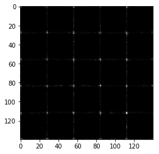

```
Iteration 110 -- Epoch 1/2 -- Discriminator loss: 1.26822 -- Generator loss: 0.62423
Iteration 120 -- Epoch 1/2 -- Discriminator loss: 1.23722 -- Generator loss: 0.64182
Iteration 130 -- Epoch 1/2 -- Discriminator loss: 1.22049 -- Generator loss: 0.64277
Iteration 140 -- Epoch 1/2 -- Discriminator loss: 1.27428 -- Generator loss: 0.61513
Iteration 150 -- Epoch 1/2 -- Discriminator loss: 1.30567 -- Generator loss: 0.55340
Iteration 160 -- Epoch 1/2 -- Discriminator loss: 1.26848 -- Generator loss: 0.62326
Iteration 170 -- Epoch 1/2 -- Discriminator loss: 1.26438 -- Generator loss: 0.67238
Iteration 180 -- Epoch 1/2 -- Discriminator loss: 1.24484 -- Generator loss: 0.62156
Iteration 190 -- Epoch 1/2 -- Discriminator loss: 1.26103 -- Generator loss: 0.62264
Iteration 200 -- Epoch 1/2 -- Discriminator loss: 1.21711 -- Generator loss: 0.64522
```

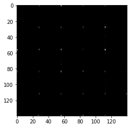

```
Iteration 210 -- Epoch 1/2 -- Discriminator loss: 1.23379 -- Generator loss: 0.67529
Iteration 220 -- Epoch 1/2 -- Discriminator loss: 1.20862 -- Generator loss: 0.63874
Iteration 230 -- Epoch 1/2 -- Discriminator loss: 1.23789 -- Generator loss: 0.62753
Iteration 240 -- Epoch 1/2 -- Discriminator loss: 1.20794 -- Generator loss: 0.66229
Iteration 250 -- Epoch 1/2 -- Discriminator loss: 1.21467 -- Generator loss: 0.67176
Iteration 260 -- Epoch 1/2 -- Discriminator loss: 1.23222 -- Generator loss: 0.65681
Iteration 270 -- Epoch 1/2 -- Discriminator loss: 1.22862 -- Generator loss: 0.62183
Iteration 280 -- Epoch 1/2 -- Discriminator loss: 1.27901 -- Generator loss: 0.62379
Iteration 290 -- Epoch 1/2 -- Discriminator loss: 1.27124 -- Generator loss: 0.68805
Iteration 300 -- Epoch 1/2 -- Discriminator loss: 1.26265 -- Generator loss: 0.67574
```

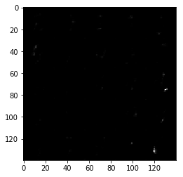

```
Iteration 310 -- Epoch 1/2 -- Discriminator loss: 1.24002 -- Generator loss: 0.65219
Iteration 320 -- Epoch 1/2 -- Discriminator loss: 1.26258 -- Generator loss: 0.67560
Iteration 330 -- Epoch 1/2 -- Discriminator loss: 1.27920 -- Generator loss: 0.63796
Iteration 340 -- Epoch 1/2 -- Discriminator loss: 1.29977 -- Generator loss: 0.66145
Iteration 350 -- Epoch 1/2 -- Discriminator loss: 1.32064 -- Generator loss: 0.61006
Iteration 360 -- Epoch 1/2 -- Discriminator loss: 1.25735 -- Generator loss: 0.62091
Iteration 370 -- Epoch 1/2 -- Discriminator loss: 1.28287 -- Generator loss: 0.66697
Iteration 380 -- Epoch 1/2 -- Discriminator loss: 1.23482 -- Generator loss: 0.66229
Iteration 390 -- Epoch 1/2 -- Discriminator loss: 1.28506 -- Generator loss: 0.57147
Iteration 400 -- Epoch 1/2 -- Discriminator loss: 1.27593 -- Generator loss: 0.62589
```

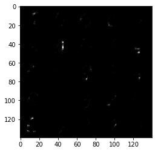

```
Iteration 410 -- Epoch 1/2 -- Discriminator loss: 1.22805 -- Generator loss: 0.63440
Iteration 420 -- Epoch 1/2 -- Discriminator loss: 1.27126 -- Generator loss: 0.66650
Iteration 430 -- Epoch 1/2 -- Discriminator loss: 1.24019 -- Generator loss: 0.64358
Iteration 440 -- Epoch 1/2 -- Discriminator loss: 1.25830 -- Generator loss: 0.62670
Iteration 450 -- Epoch 1/2 -- Discriminator loss: 1.27928 -- Generator loss: 0.62237
Iteration 460 -- Epoch 1/2 -- Discriminator loss: 1.29513 -- Generator loss: 0.64193
Iteration 470 -- Epoch 1/2 -- Discriminator loss: 1.24479 -- Generator loss: 0.66618
Iteration 480 -- Epoch 1/2 -- Discriminator loss: 1.25122 -- Generator loss: 0.67451
Iteration 490 -- Epoch 1/2 -- Discriminator loss: 1.21659 -- Generator loss: 0.64428
Iteration 500 -- Epoch 1/2 -- Discriminator loss: 1.26294 -- Generator loss: 0.68217
```

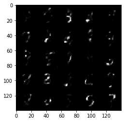

```
Iteration 510 -- Epoch 1/2 -- Discriminator loss: 1.24202 -- Generator loss: 0.66332
Iteration 520 -- Epoch 1/2 -- Discriminator loss: 1.20855 -- Generator loss: 0.67061
Iteration 530 -- Epoch 1/2 -- Discriminator loss: 1.19818 -- Generator loss: 0.65144
Iteration 540 -- Epoch 1/2 -- Discriminator loss: 1.24410 -- Generator loss: 0.61353
Iteration 550 -- Epoch 1/2 -- Discriminator loss: 1.23676 -- Generator loss: 0.65386
Iteration 560 -- Epoch 1/2 -- Discriminator loss: 1.23595 -- Generator loss: 0.59440
Iteration 570 -- Epoch 1/2 -- Discriminator loss: 1.24801 -- Generator loss: 0.66504
Iteration 580 -- Epoch 1/2 -- Discriminator loss: 1.20463 -- Generator loss: 0.67000
Iteration 590 -- Epoch 1/2 -- Discriminator loss: 1.22587 -- Generator loss: 0.67309
Iteration 600 -- Epoch 1/2 -- Discriminator loss: 1.20208 -- Generator loss: 0.67064
```

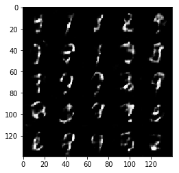

```
Iteration 610 -- Epoch 1/2 -- Discriminator loss: 1.22158 -- Generator loss: 0.66506
Iteration 620 -- Epoch 1/2 -- Discriminator loss: 1.23519 -- Generator loss: 0.63928
Iteration 630 -- Epoch 1/2 -- Discriminator loss: 1.24626 -- Generator loss: 0.57698
Iteration 640 -- Epoch 1/2 -- Discriminator loss: 1.23089 -- Generator loss: 0.63673
Iteration 650 -- Epoch 1/2 -- Discriminator loss: 1.22663 -- Generator loss: 0.64483
Iteration 660 -- Epoch 1/2 -- Discriminator loss: 1.20836 -- Generator loss: 0.61740
Iteration 670 -- Epoch 1/2 -- Discriminator loss: 1.21015 -- Generator loss: 0.66845
Iteration 680 -- Epoch 1/2 -- Discriminator loss: 1.28553 -- Generator loss: 0.67994
Iteration 690 -- Epoch 1/2 -- Discriminator loss: 1.26174 -- Generator loss: 0.57141
Iteration 700 -- Epoch 1/2 -- Discriminator loss: 1.26307 -- Generator loss: 0.67192
```

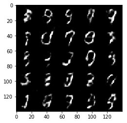

```
Iteration 710 -- Epoch 1/2 -- Discriminator loss: 1.24793 -- Generator loss: 0.68407
Iteration 720 -- Epoch 1/2 -- Discriminator loss: 1.25287 -- Generator loss: 0.67836
Iteration 730 -- Epoch 1/2 -- Discriminator loss: 1.26758 -- Generator loss: 0.68226
Iteration 740 -- Epoch 1/2 -- Discriminator loss: 1.25331 -- Generator loss: 0.63213
Iteration 750 -- Epoch 1/2 -- Discriminator loss: 1.25785 -- Generator loss: 0.65015
Iteration 760 -- Epoch 1/2 -- Discriminator loss: 1.21433 -- Generator loss: 0.65008
Iteration 770 -- Epoch 1/2 -- Discriminator loss: 1.30428 -- Generator loss: 0.57593
Iteration 780 -- Epoch 1/2 -- Discriminator loss: 1.24425 -- Generator loss: 0.66017
Iteration 790 -- Epoch 1/2 -- Discriminator loss: 1.24967 -- Generator loss: 0.58118
Iteration 800 -- Epoch 1/2 -- Discriminator loss: 1.26209 -- Generator loss: 0.65414
```

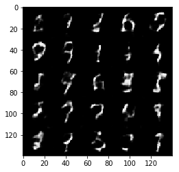

```
Iteration 810 -- Epoch 1/2 -- Discriminator loss: 1.21908 -- Generator loss: 0.68020
Iteration 820 -- Epoch 1/2 -- Discriminator loss: 1.24142 -- Generator loss: 0.65224
Iteration 830 -- Epoch 1/2 -- Discriminator loss: 1.22359 -- Generator loss: 0.65912
Iteration 840 -- Epoch 1/2 -- Discriminator loss: 1.23169 -- Generator loss: 0.64506
Iteration 850 -- Epoch 1/2 -- Discriminator loss: 1.23083 -- Generator loss: 0.67641
Iteration 860 -- Epoch 1/2 -- Discriminator loss: 1.26609 -- Generator loss: 0.62296
Iteration 870 -- Epoch 1/2 -- Discriminator loss: 1.28624 -- Generator loss: 0.60480
Iteration 880 -- Epoch 1/2 -- Discriminator loss: 1.26133 -- Generator loss: 0.67304
Iteration 890 -- Epoch 1/2 -- Discriminator loss: 1.30102 -- Generator loss: 0.61718
Iteration 900 -- Epoch 1/2 -- Discriminator loss: 1.32956 -- Generator loss: 0.67709
```

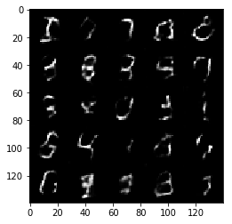

```
Iteration 910 -- Epoch 1/2 -- Discriminator loss: 1.25791 -- Generator loss: 0.65838
Iteration 920 -- Epoch 1/2 -- Discriminator loss: 1.27508 -- Generator loss: 0.66202
Iteration 930 -- Epoch 1/2 -- Discriminator loss: 1.31172 -- Generator loss: 0.68194
Iteration  10 -- Epoch 2/2 -- Discriminator loss: 1.29600 -- Generator loss: 0.56332
Iteration  20 -- Epoch 2/2 -- Discriminator loss: 1.21835 -- Generator loss: 0.61522
Iteration  30 -- Epoch 2/2 -- Discriminator loss: 1.24559 -- Generator loss: 0.65052
Iteration  40 -- Epoch 2/2 -- Discriminator loss: 1.25044 -- Generator loss: 0.62214
Iteration  50 -- Epoch 2/2 -- Discriminator loss: 1.27352 -- Generator loss: 0.64508
Iteration  60 -- Epoch 2/2 -- Discriminator loss: 1.25764 -- Generator loss: 0.63209
Iteration  70 -- Epoch 2/2 -- Discriminator loss: 1.29042 -- Generator loss: 0.62692
Iteration  80 -- Epoch 2/2 -- Discriminator loss: 1.29476 -- Generator loss: 0.62691
Iteration  90 -- Epoch 2/2 -- Discriminator loss: 1.26878 -- Generator loss: 0.63568
Iteration 100 -- Epoch 2/2 -- Discriminator loss: 1.31561 -- Generator loss: 0.67191
```

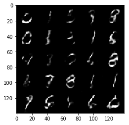

```
Iteration 110 -- Epoch 2/2 -- Discriminator loss: 1.24644 -- Generator loss: 0.64572
Iteration 120 -- Epoch 2/2 -- Discriminator loss: 1.29516 -- Generator loss: 0.67407
Iteration 130 -- Epoch 2/2 -- Discriminator loss: 1.33920 -- Generator loss: 0.55509
Iteration 140 -- Epoch 2/2 -- Discriminator loss: 1.23860 -- Generator loss: 0.64169
Iteration 150 -- Epoch 2/2 -- Discriminator loss: 1.22627 -- Generator loss: 0.63614
Iteration 160 -- Epoch 2/2 -- Discriminator loss: 1.28458 -- Generator loss: 0.66813
Iteration 170 -- Epoch 2/2 -- Discriminator loss: 1.27061 -- Generator loss: 0.65897
Iteration 180 -- Epoch 2/2 -- Discriminator loss: 1.40662 -- Generator loss: 0.56079
Iteration 190 -- Epoch 2/2 -- Discriminator loss: 1.27877 -- Generator loss: 0.62141
Iteration 200 -- Epoch 2/2 -- Discriminator loss: 1.29330 -- Generator loss: 0.65163
```

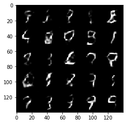

```
Iteration 210 -- Epoch 2/2 -- Discriminator loss: 1.26343 -- Generator loss: 0.64967
Iteration 220 -- Epoch 2/2 -- Discriminator loss: 1.25513 -- Generator loss: 0.62294
Iteration 230 -- Epoch 2/2 -- Discriminator loss: 1.26626 -- Generator loss: 0.64955
Iteration 240 -- Epoch 2/2 -- Discriminator loss: 1.26437 -- Generator loss: 0.60684
Iteration 250 -- Epoch 2/2 -- Discriminator loss: 1.29135 -- Generator loss: 0.65529
Iteration 260 -- Epoch 2/2 -- Discriminator loss: 1.28337 -- Generator loss: 0.62991
Iteration 270 -- Epoch 2/2 -- Discriminator loss: 1.28316 -- Generator loss: 0.63200
Iteration 280 -- Epoch 2/2 -- Discriminator loss: 1.29054 -- Generator loss: 0.59207
Iteration 290 -- Epoch 2/2 -- Discriminator loss: 1.30022 -- Generator loss: 0.67630
Iteration 300 -- Epoch 2/2 -- Discriminator loss: 1.24533 -- Generator loss: 0.66980
```

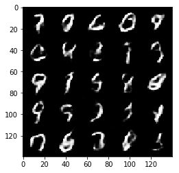

```
Iteration 310 -- Epoch 2/2 -- Discriminator loss: 1.25816 -- Generator loss: 0.65808
Iteration 320 -- Epoch 2/2 -- Discriminator loss: 1.36879 -- Generator loss: 0.68413
Iteration 330 -- Epoch 2/2 -- Discriminator loss: 1.28870 -- Generator loss: 0.56194
Iteration 340 -- Epoch 2/2 -- Discriminator loss: 1.25228 -- Generator loss: 0.64998
Iteration 350 -- Epoch 2/2 -- Discriminator loss: 1.24133 -- Generator loss: 0.62938
Iteration 360 -- Epoch 2/2 -- Discriminator loss: 1.28284 -- Generator loss: 0.60734
Iteration 370 -- Epoch 2/2 -- Discriminator loss: 1.27599 -- Generator loss: 0.62793
Iteration 380 -- Epoch 2/2 -- Discriminator loss: 1.25823 -- Generator loss: 0.67472
Iteration 390 -- Epoch 2/2 -- Discriminator loss: 1.34161 -- Generator loss: 0.68035
Iteration 400 -- Epoch 2/2 -- Discriminator loss: 1.32057 -- Generator loss: 0.64838
```

[7 more figures not shown]

```
Done!
```

```python
batch_size = 64
z_dim = 100
learning_rate = 0.0002
beta1 = 0.5


"""
DON'T MODIFY ANYTHING IN THIS CELL THAT IS BELOW THIS LINE
"""
epochs = 2

mnist_dataset = helper.Dataset('mnist', glob(os.path.join(data_dir, 'mnist/*.jpg')))
with tf.Graph().as_default():
    train(epochs, batch_size, z_dim, learning_rate, beta1, mnist_dataset.get_batches,
          mnist_dataset.shape, mnist_dataset.image_mode)
```

### CelebA

Run your GANs on CelebA. It will take around 20 minutes on the average GPU to run one epoch. You can run the whole epoch or stop when it starts to generate realistic faces.

```
Iteration  10 -- Epoch 1/1 -- Discriminator loss: 1.18781 -- Generator loss: 0.65367
Iteration  20 -- Epoch 1/1 -- Discriminator loss: 1.15627 -- Generator loss: 0.66931
Iteration  30 -- Epoch 1/1 -- Discriminator loss: 1.14501 -- Generator loss: 0.68325
Iteration  40 -- Epoch 1/1 -- Discriminator loss: 1.12528 -- Generator loss: 0.68549
Iteration  50 -- Epoch 1/1 -- Discriminator loss: 1.11432 -- Generator loss: 0.68853
Iteration  60 -- Epoch 1/1 -- Discriminator loss: 1.11384 -- Generator loss: 0.68836
Iteration  70 -- Epoch 1/1 -- Discriminator loss: 1.11068 -- Generator loss: 0.68961
Iteration  80 -- Epoch 1/1 -- Discriminator loss: 1.11583 -- Generator loss: 0.68657
Iteration  90 -- Epoch 1/1 -- Discriminator loss: 1.11321 -- Generator loss: 0.69030
Iteration 100 -- Epoch 1/1 -- Discriminator loss: 1.11507 -- Generator loss: 0.68853
```

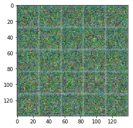

```
Iteration 110 -- Epoch 1/1 -- Discriminator loss: 1.11210 -- Generator loss: 0.68932
Iteration 120 -- Epoch 1/1 -- Discriminator loss: 1.11085 -- Generator loss: 0.68990
Iteration 130 -- Epoch 1/1 -- Discriminator loss: 1.11927 -- Generator loss: 0.68903
Iteration 140 -- Epoch 1/1 -- Discriminator loss: 1.11663 -- Generator loss: 0.68725
Iteration 150 -- Epoch 1/1 -- Discriminator loss: 1.11338 -- Generator loss: 0.69090
Iteration 160 -- Epoch 1/1 -- Discriminator loss: 1.10990 -- Generator loss: 0.69066
Iteration 170 -- Epoch 1/1 -- Discriminator loss: 1.11182 -- Generator loss: 0.69219
Iteration 180 -- Epoch 1/1 -- Discriminator loss: 1.10854 -- Generator loss: 0.69210
Iteration 190 -- Epoch 1/1 -- Discriminator loss: 1.11675 -- Generator loss: 0.68402
Iteration 200 -- Epoch 1/1 -- Discriminator loss: 1.11182 -- Generator loss: 0.68958
```

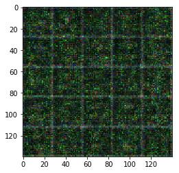

```
Iteration 210 -- Epoch 1/1 -- Discriminator loss: 1.10952 -- Generator loss: 0.69264
Iteration 220 -- Epoch 1/1 -- Discriminator loss: 1.10900 -- Generator loss: 0.69242
Iteration 230 -- Epoch 1/1 -- Discriminator loss: 1.11037 -- Generator loss: 0.69125
Iteration 240 -- Epoch 1/1 -- Discriminator loss: 1.10963 -- Generator loss: 0.69079
Iteration 250 -- Epoch 1/1 -- Discriminator loss: 1.10912 -- Generator loss: 0.69256
Iteration 260 -- Epoch 1/1 -- Discriminator loss: 1.10880 -- Generator loss: 0.69271
Iteration 270 -- Epoch 1/1 -- Discriminator loss: 1.10826 -- Generator loss: 0.69242
Iteration 280 -- Epoch 1/1 -- Discriminator loss: 1.10922 -- Generator loss: 0.69183
Iteration 290 -- Epoch 1/1 -- Discriminator loss: 1.10910 -- Generator loss: 0.69206
Iteration 300 -- Epoch 1/1 -- Discriminator loss: 1.11002 -- Generator loss: 0.69268
```

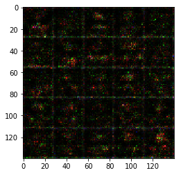

```
Iteration 310 -- Epoch 1/1 -- Discriminator loss: 1.10780 -- Generator loss: 0.69237
Iteration 320 -- Epoch 1/1 -- Discriminator loss: 1.10754 -- Generator loss: 0.69269
Iteration 330 -- Epoch 1/1 -- Discriminator loss: 1.10689 -- Generator loss: 0.69295
Iteration 340 -- Epoch 1/1 -- Discriminator loss: 1.10718 -- Generator loss: 0.69234
Iteration 350 -- Epoch 1/1 -- Discriminator loss: 1.10732 -- Generator loss: 0.69255
Iteration 360 -- Epoch 1/1 -- Discriminator loss: 1.10747 -- Generator loss: 0.69274
Iteration 370 -- Epoch 1/1 -- Discriminator loss: 1.10714 -- Generator loss: 0.69281
Iteration 380 -- Epoch 1/1 -- Discriminator loss: 1.10667 -- Generator loss: 0.69303
Iteration 390 -- Epoch 1/1 -- Discriminator loss: 1.10703 -- Generator loss: 0.69279
Iteration 400 -- Epoch 1/1 -- Discriminator loss: 1.10672 -- Generator loss: 0.69298
```

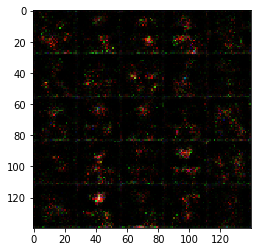

```
Iteration 410 -- Epoch 1/1 -- Discriminator loss: 1.10792 -- Generator loss: 0.69290
Iteration 420 -- Epoch 1/1 -- Discriminator loss: 1.10687 -- Generator loss: 0.69280
Iteration 430 -- Epoch 1/1 -- Discriminator loss: 1.10736 -- Generator loss: 0.69228
Iteration 440 -- Epoch 1/1 -- Discriminator loss: 1.10675 -- Generator loss: 0.69307
Iteration 450 -- Epoch 1/1 -- Discriminator loss: 1.10693 -- Generator loss: 0.69285
Iteration 460 -- Epoch 1/1 -- Discriminator loss: 1.10718 -- Generator loss: 0.69283
Iteration 470 -- Epoch 1/1 -- Discriminator loss: 1.10671 -- Generator loss: 0.69306
Iteration 480 -- Epoch 1/1 -- Discriminator loss: 1.10705 -- Generator loss: 0.69292
Iteration 490 -- Epoch 1/1 -- Discriminator loss: 1.10676 -- Generator loss: 0.69289
Iteration 500 -- Epoch 1/1 -- Discriminator loss: 1.10666 -- Generator loss: 0.69301
```

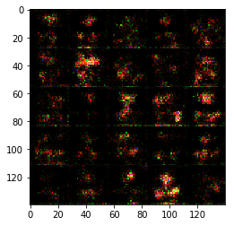

```
Iteration 510 -- Epoch 1/1 -- Discriminator loss: 1.10676 -- Generator loss: 0.69245
Iteration 520 -- Epoch 1/1 -- Discriminator loss: 1.10673 -- Generator loss: 0.69303
Iteration 530 -- Epoch 1/1 -- Discriminator loss: 1.10668 -- Generator loss: 0.69304
Iteration 540 -- Epoch 1/1 -- Discriminator loss: 1.11010 -- Generator loss: 0.69228
Iteration 550 -- Epoch 1/1 -- Discriminator loss: 1.10662 -- Generator loss: 0.69310
Iteration 560 -- Epoch 1/1 -- Discriminator loss: 1.10661 -- Generator loss: 0.69305
Iteration 570 -- Epoch 1/1 -- Discriminator loss: 1.10706 -- Generator loss: 0.69234
Iteration 580 -- Epoch 1/1 -- Discriminator loss: 1.10661 -- Generator loss: 0.69298
Iteration 590 -- Epoch 1/1 -- Discriminator loss: 1.10658 -- Generator loss: 0.69303
Iteration 600 -- Epoch 1/1 -- Discriminator loss: 1.10648 -- Generator loss: 0.69308
```

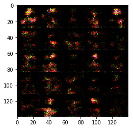

```
Iteration 610 -- Epoch 1/1 -- Discriminator loss: 1.10657 -- Generator loss: 0.69299
Iteration 620 -- Epoch 1/1 -- Discriminator loss: 1.10660 -- Generator loss: 0.69310
Iteration 630 -- Epoch 1/1 -- Discriminator loss: 1.10812 -- Generator loss: 0.69295
Iteration 640 -- Epoch 1/1 -- Discriminator loss: 1.10667 -- Generator loss: 0.69291
Iteration 650 -- Epoch 1/1 -- Discriminator loss: 1.10650 -- Generator loss: 0.69309
Iteration 660 -- Epoch 1/1 -- Discriminator loss: 1.10650 -- Generator loss: 0.69310
Iteration 670 -- Epoch 1/1 -- Discriminator loss: 1.10654 -- Generator loss: 0.69306
Iteration 680 -- Epoch 1/1 -- Discriminator loss: 1.10654 -- Generator loss: 0.69310
Iteration 690 -- Epoch 1/1 -- Discriminator loss: 1.10652 -- Generator loss: 0.69312
Iteration 700 -- Epoch 1/1 -- Discriminator loss: 1.10936 -- Generator loss: 0.68923
```

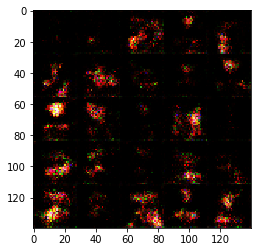

```
Iteration 710 -- Epoch 1/1 -- Discriminator loss: 1.10822 -- Generator loss: 0.69127
Iteration 720 -- Epoch 1/1 -- Discriminator loss: 1.10655 -- Generator loss: 0.69312
Iteration 730 -- Epoch 1/1 -- Discriminator loss: 1.10672 -- Generator loss: 0.69311
Iteration 740 -- Epoch 1/1 -- Discriminator loss: 1.10668 -- Generator loss: 0.69309
Iteration 750 -- Epoch 1/1 -- Discriminator loss: 1.10650 -- Generator loss: 0.69307
Iteration 760 -- Epoch 1/1 -- Discriminator loss: 1.10657 -- Generator loss: 0.69309
Iteration 770 -- Epoch 1/1 -- Discriminator loss: 1.10654 -- Generator loss: 0.69304
Iteration 780 -- Epoch 1/1 -- Discriminator loss: 1.10653 -- Generator loss: 0.69304
Iteration 790 -- Epoch 1/1 -- Discriminator loss: 1.10651 -- Generator loss: 0.69311
Iteration 800 -- Epoch 1/1 -- Discriminator loss: 1.10656 -- Generator loss: 0.69304
```

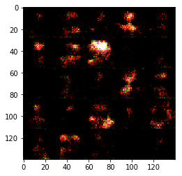

```
Iteration 810 -- Epoch 1/1 -- Discriminator loss: 1.10649 -- Generator loss: 0.69312
Iteration 820 -- Epoch 1/1 -- Discriminator loss: 1.10673 -- Generator loss: 0.69300
Iteration 830 -- Epoch 1/1 -- Discriminator loss: 1.10658 -- Generator loss: 0.69308
Iteration 840 -- Epoch 1/1 -- Discriminator loss: 1.10671 -- Generator loss: 0.69308
Iteration 850 -- Epoch 1/1 -- Discriminator loss: 1.10653 -- Generator loss: 0.69307
Iteration 860 -- Epoch 1/1 -- Discriminator loss: 1.10646 -- Generator loss: 0.69312
Iteration 870 -- Epoch 1/1 -- Discriminator loss: 1.10675 -- Generator loss: 0.69305
Iteration 880 -- Epoch 1/1 -- Discriminator loss: 1.10682 -- Generator loss: 0.69293
Iteration 890 -- Epoch 1/1 -- Discriminator loss: 1.10647 -- Generator loss: 0.69307
Iteration 900 -- Epoch 1/1 -- Discriminator loss: 1.10649 -- Generator loss: 0.69308
```

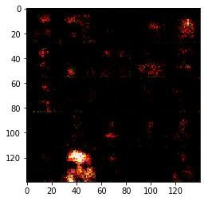

```
Iteration 910 -- Epoch 1/1 -- Discriminator loss: 1.10652 -- Generator loss: 0.69312
Iteration 920 -- Epoch 1/1 -- Discriminator loss: 1.10653 -- Generator loss: 0.69306
Iteration 930 -- Epoch 1/1 -- Discriminator loss: 1.10651 -- Generator loss: 0.69312
Iteration 940 -- Epoch 1/1 -- Discriminator loss: 1.10646 -- Generator loss: 0.69307
Iteration 950 -- Epoch 1/1 -- Discriminator loss: 1.10659 -- Generator loss: 0.69310
Iteration 960 -- Epoch 1/1 -- Discriminator loss: 1.10646 -- Generator loss: 0.69312
Iteration 970 -- Epoch 1/1 -- Discriminator loss: 1.10649 -- Generator loss: 0.69313
Iteration 980 -- Epoch 1/1 -- Discriminator loss: 1.10656 -- Generator loss: 0.69308
Iteration 990 -- Epoch 1/1 -- Discriminator loss: 1.10643 -- Generator loss: 0.69311
Iteration 1000 -- Epoch 1/1 -- Discriminator loss: 1.10652 -- Generator loss: 0.69303
```

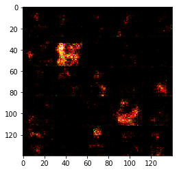

```
Iteration 1010 -- Epoch 1/1 -- Discriminator loss: 1.10653 -- Generator loss: 0.69311
Iteration 1020 -- Epoch 1/1 -- Discriminator loss: 1.10647 -- Generator loss: 0.69313
Iteration 1030 -- Epoch 1/1 -- Discriminator loss: 1.10647 -- Generator loss: 0.69312
Iteration 1040 -- Epoch 1/1 -- Discriminator loss: 1.10648 -- Generator loss: 0.69308
Iteration 1050 -- Epoch 1/1 -- Discriminator loss: 1.10645 -- Generator loss: 0.69312
Iteration 1060 -- Epoch 1/1 -- Discriminator loss: 1.10645 -- Generator loss: 0.69311
Iteration 1070 -- Epoch 1/1 -- Discriminator loss: 1.10659 -- Generator loss: 0.69297
Iteration 1080 -- Epoch 1/1 -- Discriminator loss: 1.10651 -- Generator loss: 0.69311
Iteration 1090 -- Epoch 1/1 -- Discriminator loss: 1.10653 -- Generator loss: 0.69312
Iteration 1100 -- Epoch 1/1 -- Discriminator loss: 1.10651 -- Generator loss: 0.69311
```

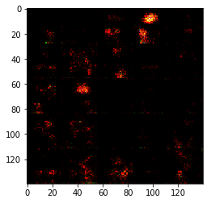

```
Iteration 1110 -- Epoch 1/1 -- Discriminator loss: 1.10646 -- Generator loss: 0.69311
Iteration 1120 -- Epoch 1/1 -- Discriminator loss: 1.10646 -- Generator loss: 0.69313
Iteration 1130 -- Epoch 1/1 -- Discriminator loss: 1.10648 -- Generator loss: 0.69311
Iteration 1140 -- Epoch 1/1 -- Discriminator loss: 1.10645 -- Generator loss: 0.69313
Iteration 1150 -- Epoch 1/1 -- Discriminator loss: 1.10648 -- Generator loss: 0.69312
Iteration 1160 -- Epoch 1/1 -- Discriminator loss: 1.10645 -- Generator loss: 0.69311
Iteration 1170 -- Epoch 1/1 -- Discriminator loss: 1.10646 -- Generator loss: 0.69312
Iteration 1180 -- Epoch 1/1 -- Discriminator loss: 1.10649 -- Generator loss: 0.69312
Iteration 1190 -- Epoch 1/1 -- Discriminator loss: 1.10647 -- Generator loss: 0.69310
Iteration 1200 -- Epoch 1/1 -- Discriminator loss: 1.10644 -- Generator loss: 0.69313
```

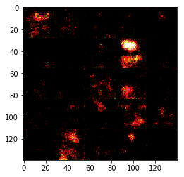

```
Iteration 1210 -- Epoch 1/1 -- Discriminator loss: 1.10651 -- Generator loss: 0.69313
Iteration 1220 -- Epoch 1/1 -- Discriminator loss: 1.10646 -- Generator loss: 0.69310
Iteration 1230 -- Epoch 1/1 -- Discriminator loss: 1.10644 -- Generator loss: 0.69313
Iteration 1240 -- Epoch 1/1 -- Discriminator loss: 1.10644 -- Generator loss: 0.69313
Iteration 1250 -- Epoch 1/1 -- Discriminator loss: 1.10653 -- Generator loss: 0.69313
Iteration 1260 -- Epoch 1/1 -- Discriminator loss: 1.10647 -- Generator loss: 0.69310
Iteration 1270 -- Epoch 1/1 -- Discriminator loss: 1.10643 -- Generator loss: 0.69314
Iteration 1280 -- Epoch 1/1 -- Discriminator loss: 1.10644 -- Generator loss: 0.69312
Iteration 1290 -- Epoch 1/1 -- Discriminator loss: 1.10645 -- Generator loss: 0.69313
Iteration 1300 -- Epoch 1/1 -- Discriminator loss: 1.10648 -- Generator loss: 0.69312
```

[52 more figures not shown]

```
Done!
```

```python
batch_size = 32
z_dim = 128
learning_rate = 0.0002
beta1 = 0.5


"""
DON'T MODIFY ANYTHING IN THIS CELL THAT IS BELOW THIS LINE
"""
epochs = 1

celeba_dataset = helper.Dataset('celeba', glob(os.path.join(data_dir, 'img_align_celeba/*.jpg')))
with tf.Graph().as_default():
    train(epochs, batch_size, z_dim, learning_rate, beta1, celeba_dataset.get_batches,
          celeba_dataset.shape, celeba_dataset.image_mode)
```

### Submitting This Project

When submitting this project, make sure to run all the cells before saving the notebook. Save the notebook file as "dlnd_face_generation.ipynb" and save it as a HTML file under "File" -> "Download as". Include the "helper.py" and "problem_unittests.py" files in your submission.